# Personal Activity Monitoring Device

JBaker

February 23, 2017

## Overview

Data from a personal activity monitoring device for 2 months (Oct & Nov 2012) are reviewed and analyzed with step-by-step commentary of the processing methods used and embedded graphics.

### Loading and preprocessing the data

Data is read and types are assigned to the data.

```r
actlog <- read.csv("./activity.csv", colClasses = c("integer", "character", "integer"))
```

### Determine the mean number of steps per day

Using the dplyr and lubridate packages to assist in summarizing the data.

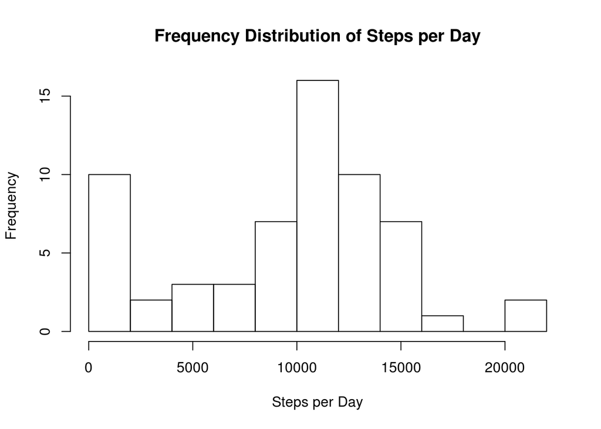

```
## [1] "Mean steps/day: 9354"
## [1] "Median steps/day: 10395"
```

```r
library(dplyr)
library(lubridate)
stepsperday <- group_by(actlog, date) %>%
        summarise(totalspd = sum(steps, na.rm = TRUE))

with(stepsperday, {
        hist(totalspd, xlab = "Steps per Day", breaks = 10,
             main = "Frequency Distribution of Steps per Day")
        print(paste0("Mean steps/day: ", round(mean(totalspd))))
        print(paste0("Median steps/day: ", median(totalspd)))
        })
```

### Daily Activity Pattern

Computing the average number of steps per daily interval. Showing the plot for average steps taken in each 5 minute interval for the two months and showing the *interval* with the maximum average steps.

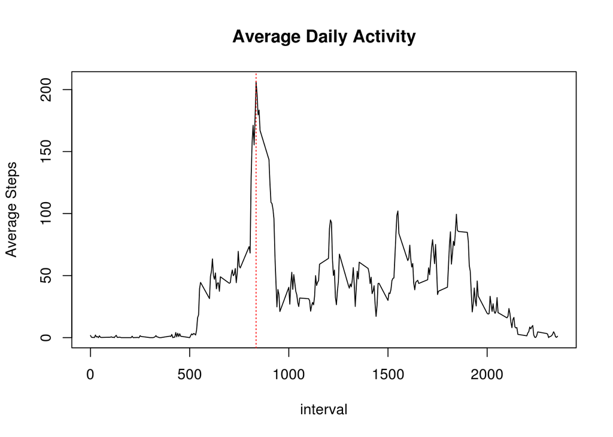

```r
avgperint <- group_by(actlog, interval) %>% summarise(pd=mean(steps, na.rm=TRUE))
plot(pd~interval, data=avgperint, type="l", ylab = "Average Steps",
        main = "Average Daily Activity")
with(avgperint, {
        busiest <- interval[which(pd == max(pd, na.rm=TRUE))]
        abline(v=busiest, col="red", lty=3)
        btime <<-format(as.POSIXct(sprintf("%04d", as.numeric(busiest)),
                                   format="%H%M"), format = "%H:%M")
})
```

The busiest time of day is 08:35

### Missing Values

There are missing values in the source data for the number of steps. There are 2304 rows with missing data. Values will be imputed to the missing elements. The mean number of steps for that time interval will be used instead.

```r
actlog_clean <- actlog                           ## Copy the original dataset
for (i in seq(1,nrow(actlog_clean))) {           ## Modify the NA elements
        if (is.na(actlog$steps[i])) {
                intv <- actlog$interval[i]
                actlog_clean$steps[i] <- avgperint$pd[avgperint$interval == intv]
        }
}
```

#### Examine the Imputed Dataset

Plotting out a histogram of the new data and it’s median and mean as a comparison to the original dataset.

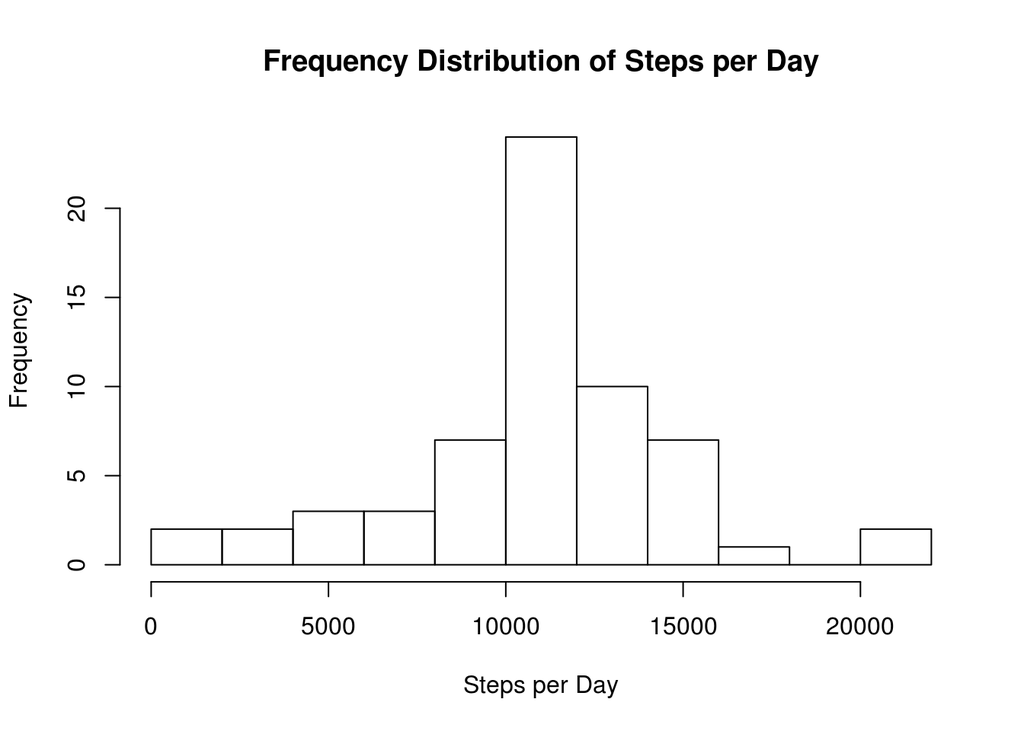

```
## [1] "Mean steps/day: 10766"
## [1] "Median steps/day: 10766"
```

```r
stepsperday1 <- group_by(actlog_clean, date) %>%
        summarise(totalspd = sum(steps, na.rm = TRUE))

with(stepsperday1, {
        hist(totalspd, xlab = "Steps per Day", breaks = 10,
             main = "Frequency Distribution of Steps per Day")
        print(paste0("Mean steps/day: ", round(mean(totalspd))))
        print(paste0("Median steps/day: ", round(median(totalspd))))
        })
```

## Weekdays vs. Weekends

Comparing the activity on weekdays as compared to weekends with two plots by interval.

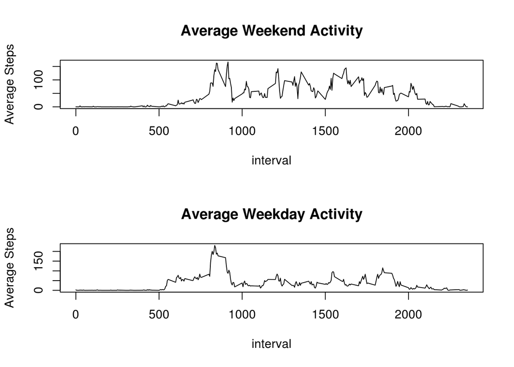

```r
actlog_clean$daytype <- factor(wday(actlog_clean$date) %in% c(1,7),
                                       labels = c("weekday", "weekend"))

avgperint_wkend <- filter(actlog_clean, daytype == "weekend") %>%
        group_by(interval) %>% summarise(pd=mean(steps))
avgperint_wkday <- filter(actlog_clean, daytype == "weekday") %>%
        group_by(interval) %>% summarise(pd=mean(steps))

par(mfrow=c(2,1))
plot(pd~interval, data=avgperint_wkend, type="l", ylab = "Average Steps",
        main = "Average Weekend Activity")
plot(pd~interval, data=avgperint_wkday, type="l", ylab = "Average Steps",
        main = "Average Weekday Activity")
```

Reviewing the charts reveals weekday activity is more concentrated around the morning. Weekend activity is more uniform throughout the day. Weekday peak activity appears to be higher.

## Summary and Challenges

A data set from a personal activity tracker were analyzed over 2 months of data. Daily patterns are reviewed and weekday vs. weekend activity compared. Some challenges for further study:

- Understand the data collection method and why there were many missing datum
- Study the weekday patterns more closely and suggest improvements in the daily routine
- Are there exercise intensity measures that should be factored in?